# The Great Easter IPA Blind Share!

2017-04-16

[figure not shown]

## Introduction

On April 15th 2017, we got together to share some of the finest IPAs we could get our hands on. In order to see what we would think of these beers without being influenced by the brewery and release hype, we decided to do a **blind share**: each of the cans was wrapped in foil wrap, and the cans were then shuffled and numbered so they could not be identified during the share. Using Google Forms, we rated each beer on a scale from 0 to 10. After all beers had been drank, I gathered the data for analysis and we had the big reveal!

Data was analyzed using a linear mixed model. The person rating the beers and the beer itself were included as random effects. I wanted to account for two factors that could influence our ratings: (1) since the flavor of IPAs is strongly influenced by hops, **freshness** could potentially predict our ratings, and (2) as we were drinking, our ratings might become more… lenient as the evening went by, and therefore the **sequence of the can in the share** could also influence our ratings. Therefore I included these two factors as fixed effects.

## The beers

[output not shown]

## Results

### Voting patterns

I calculated the intra-class correlation coefficient, which is a value between 0 and 1 that determines how much variation can be explained by that variable (another way of interpreting it is as a measure of consistency between measurements: for example, if the ICC for beers was 1 that means we all gave it the exact same score, and a value of 0 means there isn’t any pattern in our voting of beers whatsoever).

The ICC for the beers was **0.37**, which means we rated the beers relatively consistently, though with a good amount of disagreement between us.

The ICC for our rankings was **0.05**. This means nobody was giving the beers just low or just high scores, and just knowing who is voting on the beers doesn’t let you know what that vote would be like.

**In other words, putting these two things together, it seems like even though there was a lot of variation in how we voted, we were still somewhat consistent in which beers we liked and which ones we didn’t. And nobody was just giving everything the same score.**

### Beers

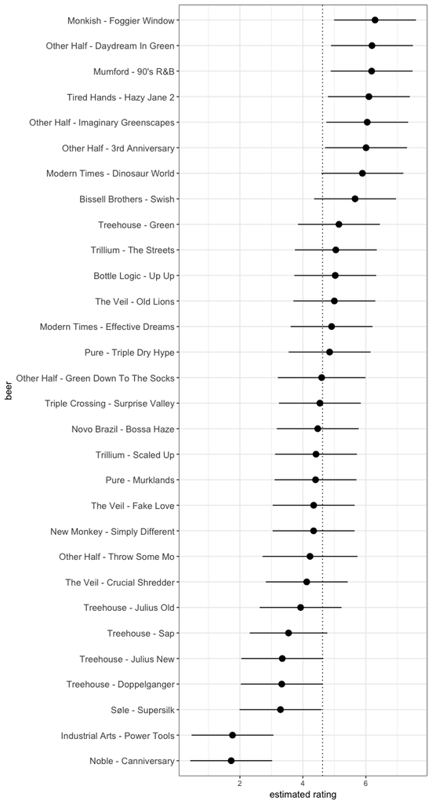

The highest scoring beer was… :drumrolls:…**Monkish - Foggier Window**! Followed closely by Other Half’s Daydream in green, imaginary greenscales and 3rd anniversary, Mumford’s 90’s R&B and Tired Hand’s Hazy Jane.

The lowest scoring beers were, by far, Noble’s CANniversary & Industrial Arts’ Power Tools, followed by Sole’s Supersilk and a bunch of Treehouse! D:

### Voters

Lars was **SAVAGE**, giving the lowest average scores :) Everyone else gave more or less scores around the same range.

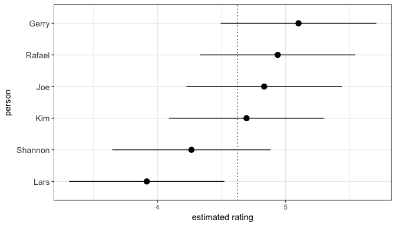

### Freshness and Sequence

Freshness was calculated as how many days had been since canning (lower values = fresher beer). Neither freshness or sequence in the share influenced our ratings.

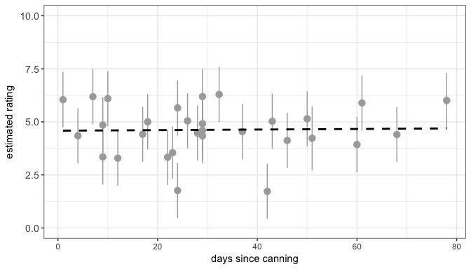

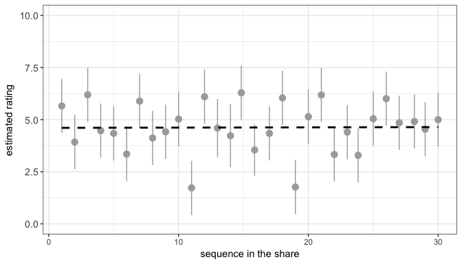

And here are each of our individual votes:

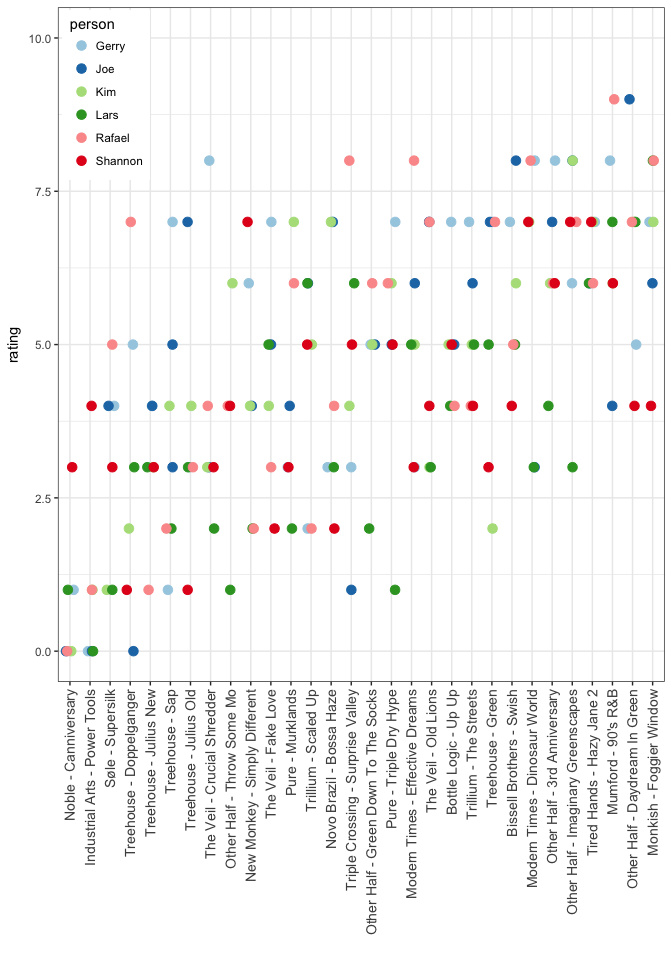